# Peer-graded Assignment: Course Project 1

sharraf eltelbani

9/24/2020

This is an R Markdown document.generated for the *Peer-graded Assignment: Course Project 1*

## First task

first task is loading the data, this chunk will first check if the data is downloaded or not and then unzips it.

```r
if (!file.exists("activity.csv") )
    {
     dlurl <- 'https://d396qusza40orc.cloudfront.net/repdata%2Fdata%2Factivity.zip'
     download.file(dlurl,destfile='repdata%2Fdata%2Factivity.zip',mode='wb')
     unzip('repdata%2Fdata%2Factivity.zip')
    }

# Read data
data <- read.csv("activity.csv")
```

We first need to restructure our data in a way that is more suitable to do analysis on, we would need to sum the steps of each day together to make our life a bit easier.

```r
num_of_steps = aggregate(steps~date,data,sum) # this puts all the steps of each day together
```

run this to check if it worked

```r
head(num_of_steps)
```

```
##         date steps
## 1 2012-10-02   126
## 2 2012-10-03 11352
## 3 2012-10-04 12116
## 4 2012-10-05 13294
## 5 2012-10-06 15420
## 6 2012-10-07 11015
```

## Secound task

This task wants a histogram of the total number of steps taken each day.  
this can be done with the “hist” command in R.

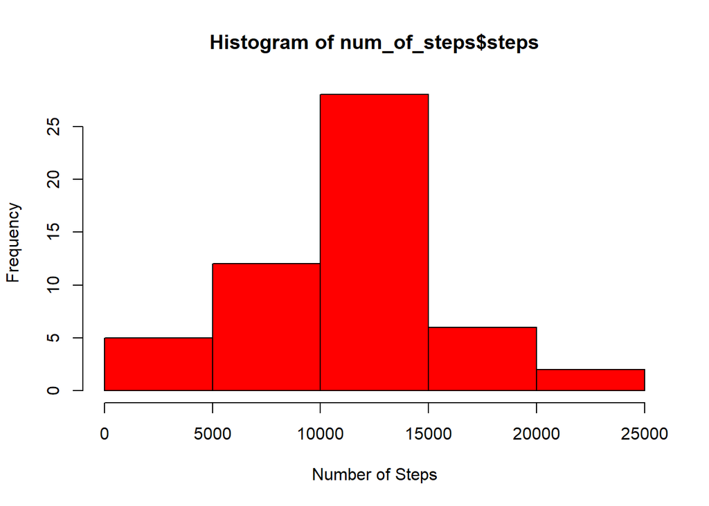

```r
hist(num_of_steps$steps,col = "red",xlab="Number of Steps")
```

last part of this task asks about the median and mean of the number of steps taken each day, this one is straight forward and can be done with a single command each

```r
med <- median(num_of_steps$steps)
men <- mean(num_of_steps$steps)
```

to view median :

```r
med
```

```
## [1] 10765
```

to view mean:

```r
men
```

```
## [1] 10766.19
```

## Third task

for this task we would need to do the same thing we did in the first task, but this time using the interval of the activity instead of date.

```r
interval = aggregate(steps~interval,data,sum)
```

now that we have the data in a neat format we can plot it!

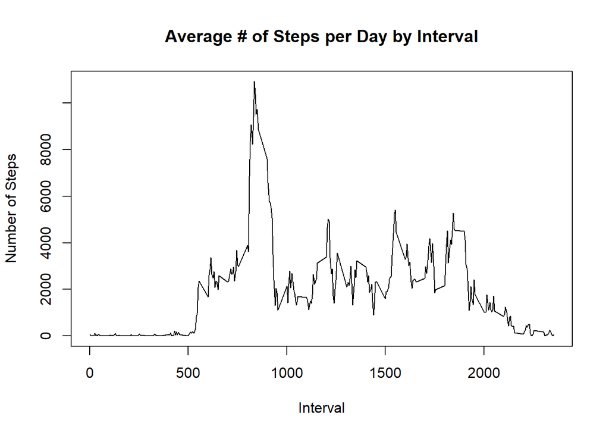

```r
plot(interval$interval,interval$steps, type="l", xlab="Interval", ylab="Number of Steps",main="Average # of Steps per Day by Interval")
```

next we need to figure out what is the the 5 minute window that has the max number of steps, R already has a “max” function for that.

```r
interval[which.max(interval$steps),1]
```

```
## [1] 835
```

## Forth task

The total number of missing values in the data set.

- for steps:

```r
sum(is.na(as.character(data$steps)))
```

```
## [1] 2304
```

- for date:

```r
sum(is.na(as.character(data$date)))
```

```
## [1] 0
```

- for interval:

```r
sum(is.na(as.character(data$interval)))
```

```
## [1] 0
```

from this its clear that only the steps have NA values, my stratigy is just putting the mean of that 5 minut interval.

```r
StepsAverage <- aggregate(steps ~ interval, data = data, FUN = mean)
fill <- numeric()
for (i in 1:nrow(data)) {
    obs <- data[i, ]
    if (is.na(obs$steps)) {
        steps <- subset(StepsAverage, interval == obs$interval)$steps
    } else {
        steps <- obs$steps
    }
    fill <- c(fill, steps)
}
```

and creating a new data set using the function that was just created:

```r
newdata <-data
newdata$steps <- fill
```

check what the outout looks like

```r
head(newdata)
```

```
##       steps       date interval
## 1 1.7169811 2012-10-01        0
## 2 0.3396226 2012-10-01        5
## 3 0.1320755 2012-10-01       10
## 4 0.1509434 2012-10-01       15
## 5 0.0754717 2012-10-01       20
## 6 2.0943396 2012-10-01       25
```

making a histogram of the new data set!

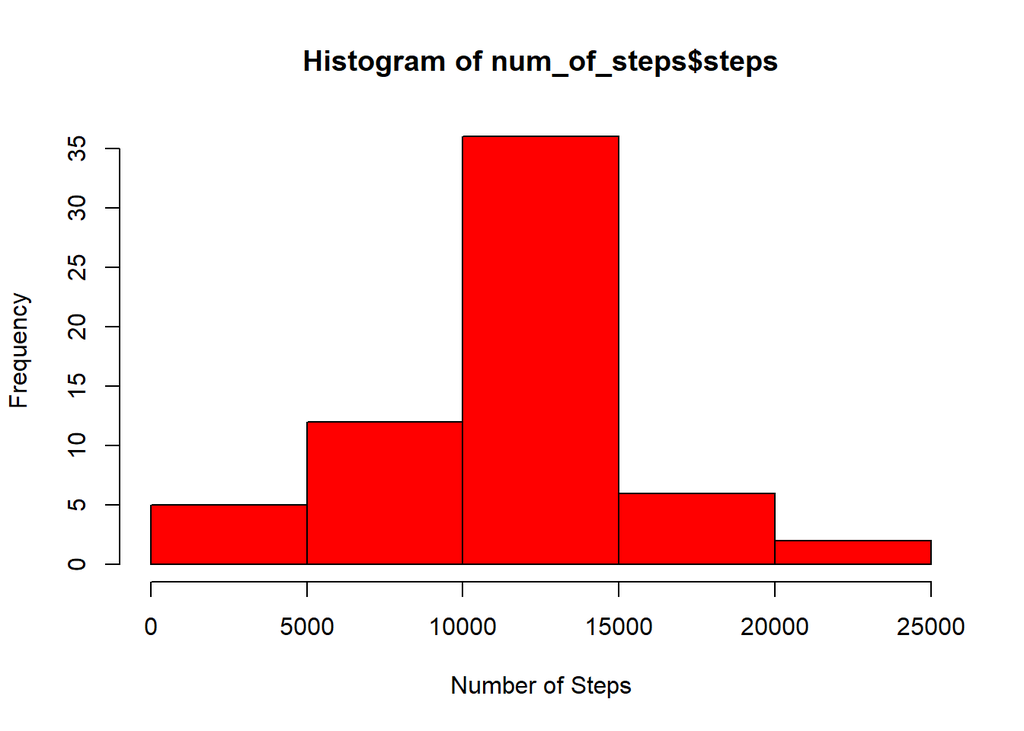

```r
num_of_steps = aggregate(steps~date,newdata,sum)
hist(num_of_steps$steps,col = "red",xlab="Number of Steps")
```

as for the new mean and median:

```r
nmed <- median(num_of_steps$steps)
nmen <- mean(num_of_steps$steps)
```

to view median :

```r
nmed
```

```
## [1] 10766.19
```

to view mean:

```r
nmen
```

```
## [1] 10766.19
```

the difference they have is:

```r
men_d <- men - nmen
med_d <- med - nmed

men_d
```

```
## [1] 0
```

```r
med_d
```

```
## [1] -1.188679
```

from that we see the mean is the same but the median is different.

## Fifth task

we need to figer out if there differences in activity patterns between weekdays and weekends?